# Data Statistic Assignment

Hugo Deroche

3/22/2020

## Simple Linear Regression

### Question 1.a)

Exploring the dataset

```r
head(data.salaries)
```

```
##   YearsExperience Salary
## 1             1.1  39343
## 2             1.3  46205
## 3             1.5  37731
## 4             2.0  43525
## 5             2.2  39891
## 6             2.9  56642
```

```r
summary(data.salaries)
```

```
##  YearsExperience      Salary
##  Min.   : 1.100   Min.   : 37731
##  1st Qu.: 3.200   1st Qu.: 56721
##  Median : 4.700   Median : 65237
##  Mean   : 5.313   Mean   : 76003
##  3rd Qu.: 7.700   3rd Qu.:100545
##  Max.   :10.500   Max.   :122391
```

```r
str(data.salaries)
```

```
## 'data.frame':    30 obs. of  2 variables:
##  $ YearsExperience: num  1.1 1.3 1.5 2 2.2 2.9 3 3.2 3.2 3.7 ...
##  $ Salary         : int  39343 46205 37731 43525 39891 56642 60150 54445 64445 57189 ...
```

The first variable is the Years of experience (type = numeric)

The second variable is the Salary of people depending on their experience (type = integer)

*Plotting the data of ‘salaries.csv’*

I will plot the Salary against the Years of Experience, which seems like the most relevant plot to make because usually the salary depends on the experience.

All the data will be displayed in euro/year

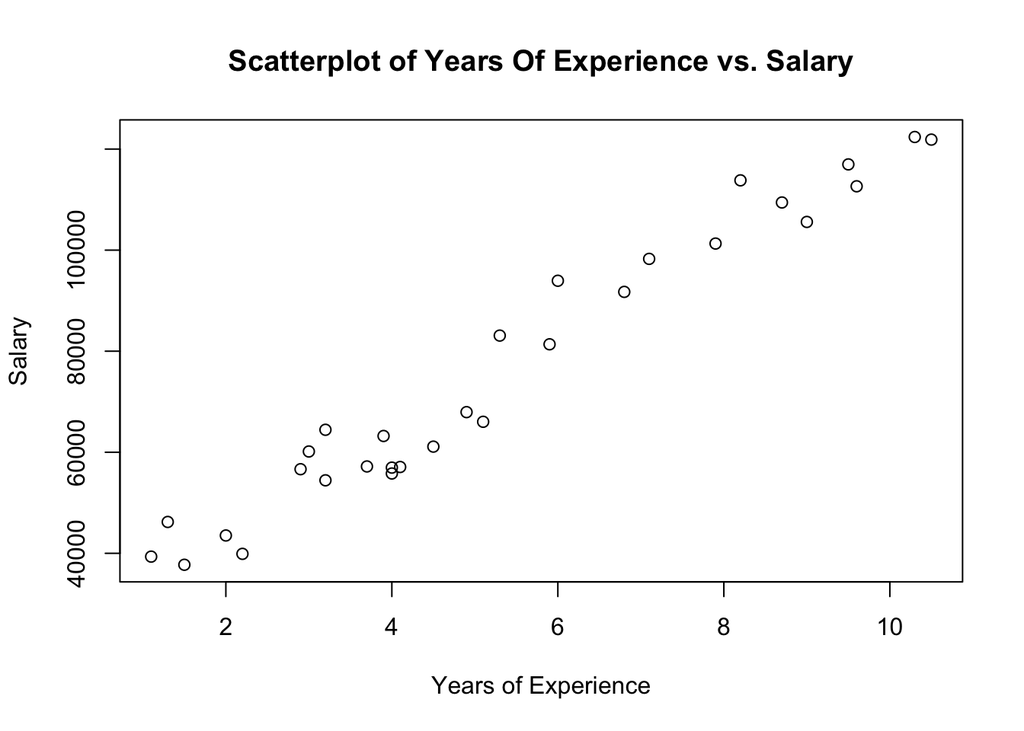

Considering the plot, we can clearly see a linear trend, so a linear regression can be a good estimate for this set of variables.

Also we can see that there seem to be no outliers, so no tuple need to be removed

### Question 1.b)

**Least squared method**

In this section, I will determine the best fit function (slope and intercept) by calculing the S_xx, S_yy and S_xy In order to simplify, I will assign $x=YearsOfExperience$ to x and $y=Salary$ and $n=length(Salary)$
$$S_{xy} = \sum(x * y) - \frac{\sum x * \sum y}{n}$$
$$S_{yy} = \sum y^2 - \frac{ \sum y^2}{n}$$
$$S_{xx} = \sum x^2 - \frac{ \sum x^2}{n}$$

```r
S_xy <- sum(x * y) - (sum(x) * sum(y)) / n
S_xx <- sum(x^2) - sum(x)^2 / n
S_yy <- sum(y^2) - sum(y)^2 / n
```

```
##            S_xy     S_xx        S_yy
## Results 2207083 233.5547 21794977852
```

Then the best fit slope is : $b=\frac{S_{xy}}{S_{xx}}$

And the best fit intercept is : $a = mean(y) - b*mean(x)$

```r
b <- S_xy/S_xx
a <- mean(y) - b*mean(x)
```

```
##         a (intercept) b (slope)
## Results       25792.2  9449.962
```

$$\beta_0 = a = 25792.2$$

$$\beta_1 = b = 9449.962$$

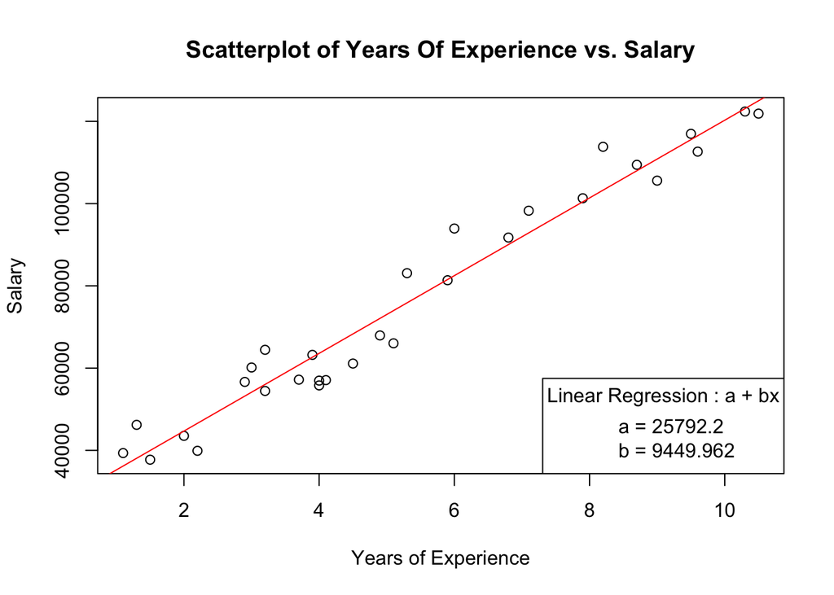

**Interpretation :**

Every year we can expect one person have a salary bonus of 10k. And a young employee with no experience would have a salary around 25k to start.

### Question 1.c)

By using the summary function on the lm function we will be able to determine if the hypothesis test is verified or not

```r
model = lm(y ~ x, data = data.salaries)
summary(model)
```

```
##
## Call:
## lm(formula = y ~ x, data = data.salaries)
##
## Residuals:
##     Min      1Q  Median      3Q     Max
## -7958.0 -4088.5  -459.9  3372.6 11448.0
##
## Coefficients:
##             Estimate Std. Error t value Pr(>|t|)
## (Intercept)  25792.2     2273.1   11.35 5.51e-12 ***
## x             9450.0      378.8   24.95  < 2e-16 ***
## ---
## Signif. codes:  0 '***' 0.001 '**' 0.01 '*' 0.05 '.' 0.1 ' ' 1
##
## Residual standard error: 5788 on 28 degrees of freedom
## Multiple R-squared:  0.957,  Adjusted R-squared:  0.9554
## F-statistic: 622.5 on 1 and 28 DF,  p-value: < 2.2e-16
```

First of all, we can see that the estimate best fit slope and intercept are close to the one we found in the previous question

Intercept = 25792.2 €

Slope = 9450 €

Our hypothesis are

- Ho hypothesis is that $\beta_0 = \beta_1$
- H1 : at least one of them is != 0

We hope to reject Ho

Conclusion : p value < $\alpha$ = 0.05 So we can reject Ho.

### Question 1.d)

In order to find the R^2 value, we will need to evaluate some intermediate results such as : Some of these results will be needed for later calculations.

- SST : Sum of squares of total
- SSE : Sum of squares of errors
- MSE : Mean of Square of Errors
- SE : Square-root of MSE

Note : SSR : Sum of squares of regression : SRR = SST - SSE

**R-Squared**

```r
# In order to apply the formula of R-Squared we need to do some prior calculations
SST = sum((y - mean(y))^2)
y.hat = model$fitted.values # Getting the value from the model
SSE <- sum((y - y.hat)^2)
SE <- sqrt(SSE / (n-2))
r2 = 1 - SSE/SST
```

```
## [1] 0.9569567
```

```
##
## Call:
## lm(formula = y ~ x, data = data.salaries)
##
## Residuals:
##     Min      1Q  Median      3Q     Max
## -7958.0 -4088.5  -459.9  3372.6 11448.0
##
## Coefficients:
##             Estimate Std. Error t value Pr(>|t|)
## (Intercept)  25792.2     2273.1   11.35 5.51e-12 ***
## x             9450.0      378.8   24.95  < 2e-16 ***
## ---
## Signif. codes:  0 '***' 0.001 '**' 0.01 '*' 0.05 '.' 0.1 ' ' 1
##
## Residual standard error: 5788 on 28 degrees of freedom
## Multiple R-squared:  0.957,  Adjusted R-squared:  0.9554
## F-statistic: 622.5 on 1 and 28 DF,  p-value: < 2.2e-16
```

Given the values of Pr(>|t|) which are smaller than $\alpha$, we can affirm that the model we found is a sufficiant model given the level of significance : 0.05.

**Note :**

The calulated value of R^2 is very close to the value that the lm() model gives us.

R^2 is very close to 1 (~ 0.957) so 95% of the salary’s variation is explained by the Years of Experience

**A Linear Model is a good estimate for this dataset.**

```r
cor(data.salaries)
```

```
##                 YearsExperience    Salary
## YearsExperience       1.0000000 0.9782416
## Salary                0.9782416 1.0000000
```

Moreover the correlation between these two variables is very close to 1, so these two parameters are linked in some way.

### Question 1.e)

The new employee has 6.5 years of experience and wants to know what he should expect.

In order to calculate the prediction point, we have to use the linear regression we have found and use $a + b*6.5$

**Point prediction**

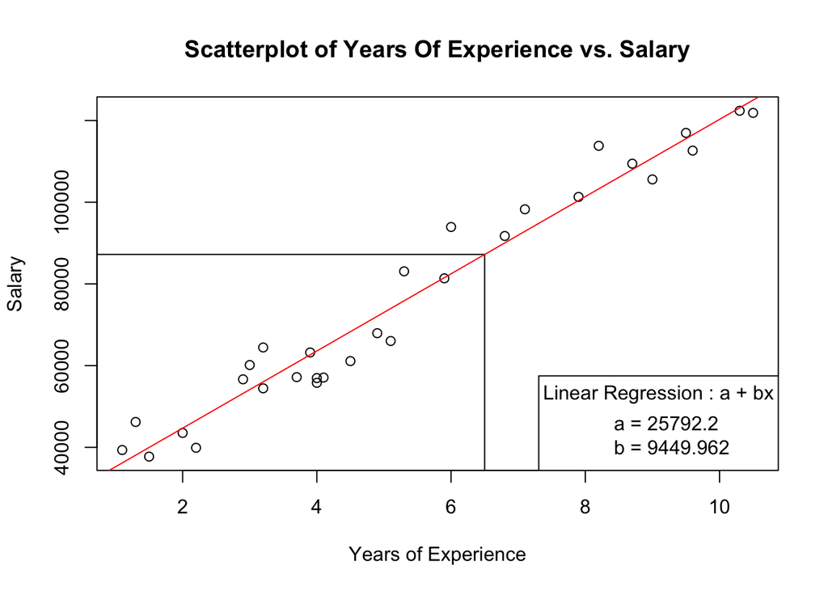

```r
{plot(x, y, main = "Scatterplot of Years Of Experience vs. Salary",
     xlab = "Years of Experience",
     ylab = "Salary", )
  segments(0,a + b*6.5, 6.5, a + b*6.5)
  segments(6.5,0,6.5,a + b*6.5)
  abline(a, b, col='red')
  legend("bottomright", legend=c(aTxt, bTxt), title='Linear Regression : a + bx')}
```

```r
newEmployee.salary = a + b*6.5
```

```
## The prediction point for a new employee of 6.5 years of experience is :  87216.96 €
```

A new employee with 6.5 years of experience would expect to have a salary of $87216.96$ (prediction point)

**95% confidence Interval**

$$\bar{X} \pm \delta = \bar{X} \pm Z\frac{s}{\sqrt{n}}$$
X.bar = Mean Z = Value for 95% interval : 1.96 s = Standard deviation n = Number of observations

```r
# Using the student table, with 97.5% in the two-sided column in order to have a 5% around the best fit line
t28 <- qt(0.975,df=n-2)

MSE <- SSE / (n-2)
x.bar=mean(x)
confidence6.5= t28 * sqrt(MSE*( (1/n) + (6.5 - x.bar )^2/ sum( (x-x.bar)^2 ) ))

Conf = matrix( c(a + b*6.5, a + b*6.5 - confidence6.5, a + b*6.5 + confidence6.5),  nrow=1, ncol=3, byrow = TRUE)
dimnames(Conf) = list(c('Confidence results for 6.5 YoE'), c('Fit', 'Lower', 'Upper'))
Conf
```

```
##                                     Fit    Lower    Upper
## Confidence results for 6.5 YoE 87216.96 84864.56 89569.35
```

```r
# Verification using the built-in function

conf6.5 <- predict(model, newdata = data.frame(x = 6.5), interval = 'confidence')
conf6.5
```

```
##        fit      lwr      upr
## 1 87216.96 84864.56 89569.35
```

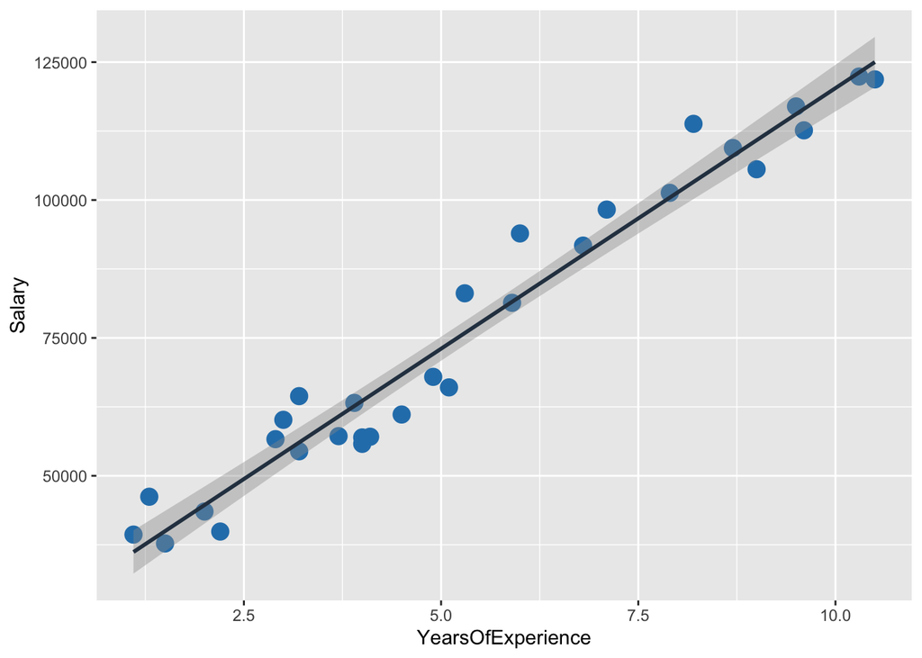

```r
# Generating the result for all the points in the data frame
confidence <- predict(model, data.frame(data.salaries$Salary), interval = 'confidence')

library(ggplot2)
ggplot(data.salaries, aes(x=YearsOfExperience, y=Salary)) +
  geom_point(color='#2980B9', size = 4) +
  geom_smooth(method=lm, color='#2C3E50')
```

We can see of the plot above that the confidence intervall is narrower at the mean and wider at the ends.

**95% prediction Interval**

The Prediction Interval is a range of values where the prediction point is 95% likely to be in this range.

It consists in drawing two parallels and keeping a chanel with 5% above and below the best fit line.

```r
# By using the Student's t-distribution we find t30-2 : t28 : 2.048 (two-sided)
prediction6.5= t28 * sqrt(MSE*( 1 + (1/n) + (6.5 - x.bar )^2/ sum( (x-x.bar)^2 ) ))

Pred = matrix( c(a + b*6.5, a + b*6.5 - prediction6.5, a + b*6.5 + prediction6.5),  nrow=1, ncol=3, byrow = TRUE)
dimnames(Pred) = list(c('Prediction results for 6.5 YoE'), c('Fit', 'Lowerr', 'Upper'))
Pred
```

```
##                                     Fit   Lowerr    Upper
## Prediction results for 6.5 YoE 87216.96 75129.02 99304.89
```

```r
# verification using the built-in function
pred6.5 <- predict(model, newdata = data.frame(x = 6.5), interval = 'prediction')
pred6.5
```

```
##        fit      lwr      upr
## 1 87216.96 75129.02 99304.89
```

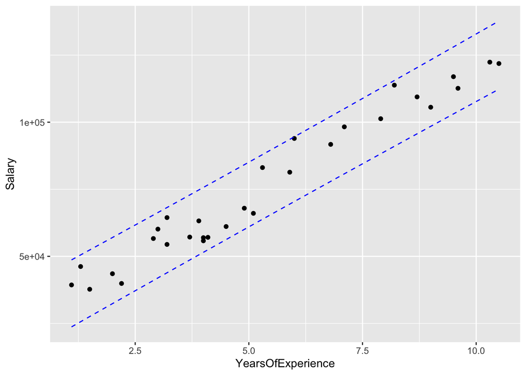

```r
# Generating all the prediction points from all the data
prediction <- predict(model,data.frame(YearsOfExperience), interval = 'prediction')

ggplot(data.salaries, aes(x=YearsOfExperience, y=Salary))+
    geom_point() +
    geom_line(aes(y=prediction[,2]), color = "blue", linetype = "dashed")+
    geom_line(aes(y=prediction[,3]), color = "blue", linetype = "dashed")
```

The higher and lower prediction lines represents a channel, for which all the predicted value can be located, with a 95% confidance rate.

### Question 1.f)

We can’t use the model because we can not extrapolate the data as it may be not relevant and the model is linear for the first 10 years of experience but it may be logaritmic for the next decade. If we were to keep this model this person would have a salary of :

```r
salary.thirty <- a + b * 30
salary.thirty
```

```
## [1] 309291.1
```

The prediction point for a 30-year experience is $309291.1$

Maybe the curve is logarithmic after the 10 years of experience, as it might cap at some point.

To solve the problem we would need to have more data from the company with people who have more experience. It would be even better if we had some data of people with 30+ years of experience, so that we can interpolate and predict the salary correctly

### Question 1.g)

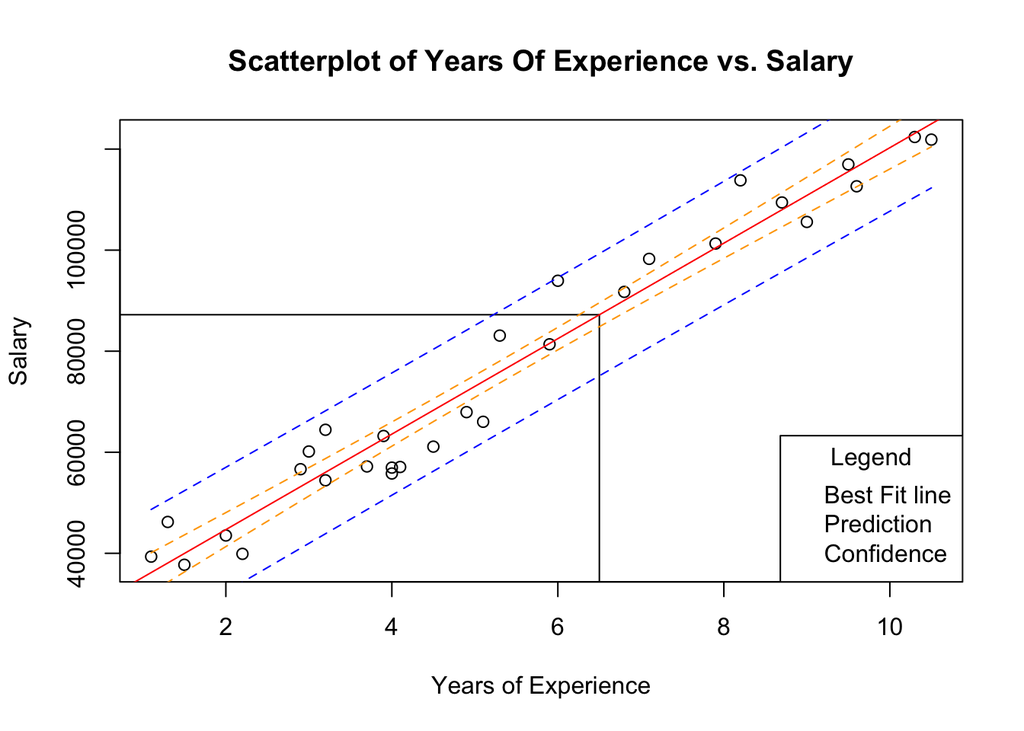

```r
# Plotting the final results
{plot(x, y, main = "Scatterplot of Years Of Experience vs. Salary",
     xlab = "Years of Experience",
     ylab = "Salary", )
  segments(0,a + b*6.5, 6.5, a + b*6.5)
  segments(6.5,0,6.5,a + b*6.5)
  abline(model, col='red')
  lines(x, prediction[,2], col="blue", lty=2)
  lines(x, prediction[,3], col="blue", lty=2)
  lines(x, confidence[,2], col="orange", lty=2)
  lines(x, confidence[,3], col="orange", lty=2)
  legend("bottomright", legend=c('Best Fit line', 'Prediction', 'Confidence'), col=c('red', 'blue', 'orange'), title='Legend')
  }
```

## Question 2)

### Introduction

We are asked by an insurance company to extract from this dataset a model in order to predict the expense given the profile of the person. We are given 6 variables and we have to rearrange, clear, and use the data to have a relevant model to give to the insurance company.

The variable to predict is **expense**

We will choose arbitrarily to train our data on 70% of the data and to test it on the 30% remaining.

The steps that I will go throught will be :

- Exploring the dataset
- Building a model
- Testing the model
- Add some interractions
- Test prediction

### Exploring the dataset

I need to explore the dataset in order to know which variable this dataset have.

```r
# Looking at the data
head(medical)
```

```
##   age    sex  bmi children smoker    region expenses
## 1  19 female 27.9        0    yes southwest 16884.92
## 2  18   male 33.8        1     no southeast  1725.55
## 3  28   male 33.0        3     no southeast  4449.46
## 4  33   male 22.7        0     no northwest 21984.47
## 5  32   male 28.9        0     no northwest  3866.86
## 6  31 female 25.7        0     no southeast  3756.62
```

```r
summary(medical)
```

```
##       age            sex           bmi           children     smoker
##  Min.   :18.00   female:662   Min.   :16.00   Min.   :0.000   no :1064
##  1st Qu.:27.00   male  :676   1st Qu.:26.30   1st Qu.:0.000   yes: 274
##  Median :39.00                Median :30.40   Median :1.000
##  Mean   :39.21                Mean   :30.67   Mean   :1.095
##  3rd Qu.:51.00                3rd Qu.:34.70   3rd Qu.:2.000
##  Max.   :64.00                Max.   :53.10   Max.   :5.000
##        region       expenses
##  northeast:324   Min.   : 1122
##  northwest:325   1st Qu.: 4740
##  southeast:364   Median : 9382
##  southwest:325   Mean   :13270
##                  3rd Qu.:16640
##                  Max.   :63770
```

```r
str(medical)
```

```
## 'data.frame':    1338 obs. of  7 variables:
##  $ age     : int  19 18 28 33 32 31 46 37 37 60 ...
##  $ sex     : Factor w/ 2 levels "female","male": 1 2 2 2 2 1 1 1 2 1 ...
##  $ bmi     : num  27.9 33.8 33 22.7 28.9 25.7 33.4 27.7 29.8 25.8 ...
##  $ children: int  0 1 3 0 0 0 1 3 2 0 ...
##  $ smoker  : Factor w/ 2 levels "no","yes": 2 1 1 1 1 1 1 1 1 1 ...
##  $ region  : Factor w/ 4 levels "northeast","northwest",..: 4 3 3 2 2 3 3 2 1 2 ...
##  $ expenses: num  16885 1726 4449 21984 3867 ...
```

We can notice that we have some categorical variables, so we will have to make dummy variables by using the factor function

The sex, smoker, and region are categorical variables

```r
# Factorising the data
medical$sex = factor(medical$sex)
medical$smoker = factor(medical$smoker)
medical$region = factor(medical$region)
str(medical)
```

```
## 'data.frame':    1338 obs. of  7 variables:
##  $ age     : int  19 18 28 33 32 31 46 37 37 60 ...
##  $ sex     : Factor w/ 2 levels "female","male": 1 2 2 2 2 1 1 1 2 1 ...
##  $ bmi     : num  27.9 33.8 33 22.7 28.9 25.7 33.4 27.7 29.8 25.8 ...
##  $ children: int  0 1 3 0 0 0 1 3 2 0 ...
##  $ smoker  : Factor w/ 2 levels "no","yes": 2 1 1 1 1 1 1 1 1 1 ...
##  $ region  : Factor w/ 4 levels "northeast","northwest",..: 4 3 3 2 2 3 3 2 1 2 ...
##  $ expenses: num  16885 1726 4449 21984 3867 ...
```

Let’s take a look at their correlation by plotting the dataset and by calling the correlation function :

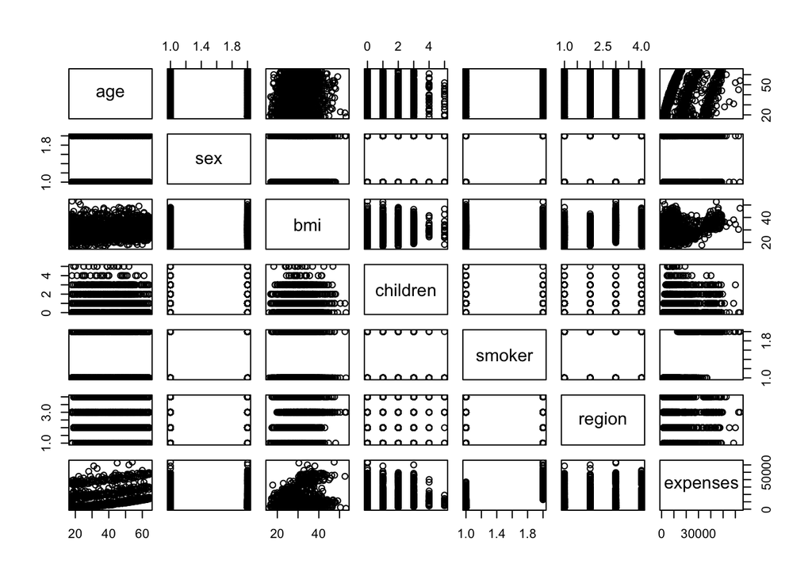

```r
plot(medical)
```

### Building the model

Now that we converted the categorical variables by factors and dummy variables, we can build a model
$$y = \beta_{0} + x_{1}\beta_{1} + x_{2}\beta_{2} ... + x_{n}\beta_{n}$$

```r
cor(medical$expenses, medical$age)
```

```
## [1] 0.2990082
```

```r
# First Model
set.seed(1799)
n <- nrow(medical)
index <- sample(1:n, floor(n * 0.7))
length(index)
```

```
## [1] 936
```

```r
train <- medical[index, ]
test <- medical[-index, ]

model <- lm(expenses ~ .,data = train)
summary(model)
```

```
##
## Call:
## lm(formula = expenses ~ ., data = train)
##
## Residuals:
##      Min       1Q   Median       3Q      Max
## -11928.1  -2706.7   -943.6   1468.7  29315.7
##
## Coefficients:
##                  Estimate Std. Error t value Pr(>|t|)
## (Intercept)     -11457.30    1164.99  -9.835  < 2e-16 ***
## age                251.01      13.90  18.064  < 2e-16 ***
## sexmale            307.32     391.42   0.785  0.43256
## bmi                339.52      33.53  10.125  < 2e-16 ***
## children           363.59     163.28   2.227  0.02620 *
## smokeryes        24279.30     495.07  49.042  < 2e-16 ***
## regionnorthwest   -891.58     566.88  -1.573  0.11611
## regionsoutheast  -1468.89     561.93  -2.614  0.00909 **
## regionsouthwest  -1791.19     562.72  -3.183  0.00151 **
## ---
## Signif. codes:  0 '***' 0.001 '**' 0.01 '*' 0.05 '.' 0.1 ' ' 1
##
## Residual standard error: 5978 on 927 degrees of freedom
## Multiple R-squared:  0.7574, Adjusted R-squared:  0.7553
## F-statistic: 361.7 on 8 and 927 DF,  p-value: < 2.2e-16
```

```r
AIC(model)
```

```
## [1] 18945.71
```

The Pr(>|t|) value can indicate which parameter is relevant or not, we will use the same significance level as the previous exercice which is $\alpha = 0.05$

So, for this significance level the sex variable is not relevant. However we can’t remove the region variable because only one of the factor has a Pr-value above the significance level.

We will now try to improve the model by removing the sex variable, and try most of the combination of variable to have the lowest AIC. The lower the AIC, the better the model is.

```r
# Improving the model
model1 = lm(expenses ~ age + bmi + region + children + smoker, data = train)
AIC(model1) # better AIC than with the sex variable
```

```
## [1] 18944.33
```

The model without the sex variable has a lower AIC so it is fondamentaly better, even though the AIC only reduced by ~1

Now, let’s proceed to a backward selection to remove the unnecessary data to the model We will remove 1 by 1 the variable and test the AIC to each of them We will choose the model that has the lowest AIC

```r
# Eventually testing for better models
model2 = lm(expenses ~ bmi + region + children + smoker, data = train) # without age
model3 = lm(expenses ~ age + region + children + smoker, data = train) # without bmi
model4 = lm(expenses ~ age + bmi + children +  smoker, data = train)  # without region
model5 = lm(expenses ~ age + bmi + region + smoker, data = train) # without children
model6 = lm(expenses ~ age + bmi + region + children , data = train) # without smoker
```

```r
Aic
```

```
##               Model 1 : ref Model 2  Model 3  Model 4  Model 5  Model 6
## AIC Results :      18944.33 19224.2 19040.69 18949.85 18947.35 20142.02
```

Given the result, we can not remove any variable as the AIC gets higher as we remove parameters. So the best model we have found is the one without the sex variable.

Model1 is the best model.

```r
summary(model1)
```

```
##
## Call:
## lm(formula = expenses ~ age + bmi + region + children + smoker,
##     data = train)
##
## Residuals:
##      Min       1Q   Median       3Q      Max
## -11785.6  -2730.8   -968.9   1396.0  29454.0
##
## Coefficients:
##                  Estimate Std. Error t value Pr(>|t|)
## (Intercept)     -11316.27    1150.82  -9.833  < 2e-16 ***
## age                250.86      13.89  18.058  < 2e-16 ***
## bmi                339.92      33.52  10.141  < 2e-16 ***
## regionnorthwest   -885.03     566.70  -1.562  0.11869
## regionsoutheast  -1465.21     561.79  -2.608  0.00925 **
## regionsouthwest  -1786.87     562.58  -3.176  0.00154 **
## children           364.45     163.24   2.233  0.02581 *
## smokeryes        24298.02     494.39  49.147  < 2e-16 ***
## ---
## Signif. codes:  0 '***' 0.001 '**' 0.01 '*' 0.05 '.' 0.1 ' ' 1
##
## Residual standard error: 5976 on 928 degrees of freedom
## Multiple R-squared:  0.7572, Adjusted R-squared:  0.7554
## F-statistic: 413.4 on 7 and 928 DF,  p-value: < 2.2e-16
```

We can now extract all the data from this model and test it on our test data.

### Testing the model

```r
deviance(model1)
```

```
## [1] 33145704417
```

```r
anova(model1, test = "Chisq")
```

```
## Analysis of Variance Table
##
## Response: expenses
##            Df     Sum Sq    Mean Sq   F value    Pr(>F)
## age         1 1.1291e+10 1.1291e+10  316.1164 < 2.2e-16 ***
## bmi         1 4.7016e+09 4.7016e+09  131.6321 < 2.2e-16 ***
## region      3 6.0674e+08 2.0225e+08    5.6624 0.0007614 ***
## children    1 4.9612e+08 4.9612e+08   13.8901 0.0002055 ***
## smoker      1 8.6273e+10 8.6273e+10 2415.4334 < 2.2e-16 ***
## Residuals 928 3.3146e+10 3.5717e+07
## ---
## Signif. codes:  0 '***' 0.001 '**' 0.01 '*' 0.05 '.' 0.1 ' ' 1
```

The ANOVA Model returns a value of the same magnitude as the deviance (residuals) : 3.3e+10 The hypothesis of the model : - Ho : deviance close to the Chi-squared -> Good model - H1 : no relation between the deviance and the Chi-squared value

Moreover the Pr(>F) (Fisher Test) value show that all the data is below the significance level of $\alpha = 0.05$ We fail to reject Ho so we can say that the model is good enough.

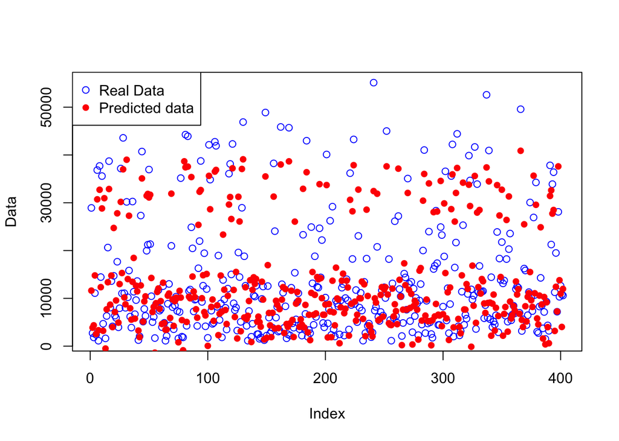

```r
coeffs <- model1$coefficients

predicted.data <- predict(model1, newdata = test)
real.data <- test$expenses
diff.data <- abs(predicted.data - real.data)

{plot(real.data, ylab = 'Data', col='blue')
points(predicted.data, col='red', pch=16)
legend('topleft', legend = c('Real Data', 'Predicted data'), col=c('blue', 'red'), bty = n, pch=c(1,16))}
```

This plot shows the repartition of the point given their index, the reference repartition is in blue and the predicted one is in red. The closer the red dots are from the blue one, the better.

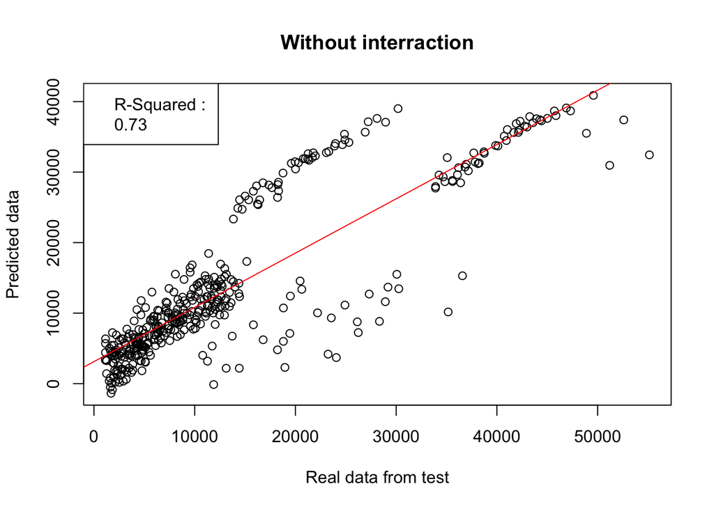

```
## accuracy :  73  %
```

```r
# Plotting the predicted values against the real data

mod.nointerraction <- lm(predicted.data ~ real.data)
{plot(real.data, predicted.data, xlab = 'Real data from test', ylab = 'Predicted data', title('Without interraction'))
  abline(a = mod.nointerraction$coefficients[1], b = mod.nointerraction$coefficients[2], col='red')
  legend('topleft', legend = c('R-Squared : ', round(summary(mod.nointerraction)$r.squared, 2)))}
```

### Interractions

Now, let’s add the interraction to the model

In order to add interraction between two or more variables, we have to ask ourselves two questions :

- Does the interraction make sense conceptually ?
- Is the interraction term statistically significant ?

If the answer is yes for both then we can add the interraction term in the model.

For the bmi and smoker variables they seem to be interracting between each other, a smoking person might have a worst physical condition age and bmi

```r
str(medical)
```

```
## 'data.frame':    1338 obs. of  7 variables:
##  $ age     : int  19 18 28 33 32 31 46 37 37 60 ...
##  $ sex     : Factor w/ 2 levels "female","male": 1 2 2 2 2 1 1 1 2 1 ...
##  $ bmi     : num  27.9 33.8 33 22.7 28.9 25.7 33.4 27.7 29.8 25.8 ...
##  $ children: int  0 1 3 0 0 0 1 3 2 0 ...
##  $ smoker  : Factor w/ 2 levels "no","yes": 2 1 1 1 1 1 1 1 1 1 ...
##  $ region  : Factor w/ 4 levels "northeast","northwest",..: 4 3 3 2 2 3 3 2 1 2 ...
##  $ expenses: num  16885 1726 4449 21984 3867 ...
```

```r
model.interraction <- lm(expenses ~ age + region + children + smoker + smoker:bmi, data = train)
AIC(model.interraction)
```

```
## [1] 18549.93
```

```r
summary(model.interraction)
```

```
##
## Call:
## lm(formula = expenses ~ age + region + children + smoker + smoker:bmi,
##     data = train)
##
## Residuals:
##      Min       1Q   Median       3Q      Max
## -13495.5  -1917.9  -1218.3   -397.9  30361.1
##
## Coefficients:
##                  Estimate Std. Error t value Pr(>|t|)
## (Intercept)      -2322.88    1016.63  -2.285 0.022544 *
## age                261.46      11.26  23.227  < 2e-16 ***
## regionnorthwest   -669.92     458.90  -1.460 0.144675
## regionsoutheast  -1386.57     454.84  -3.048 0.002365 **
## regionsouthwest  -1707.48     455.48  -3.749 0.000189 ***
## children           395.51     132.17   2.992 0.002840 **
## smokeryes       -18799.61    1989.98  -9.447  < 2e-16 ***
## smokerno:bmi        31.07      30.52   1.018 0.309007
## smokeryes:bmi     1413.66      55.63  25.410  < 2e-16 ***
## ---
## Signif. codes:  0 '***' 0.001 '**' 0.01 '*' 0.05 '.' 0.1 ' ' 1
##
## Residual standard error: 4838 on 927 degrees of freedom
## Multiple R-squared:  0.841,  Adjusted R-squared:  0.8397
## F-statistic:   613 on 8 and 927 DF,  p-value: < 2.2e-16
```

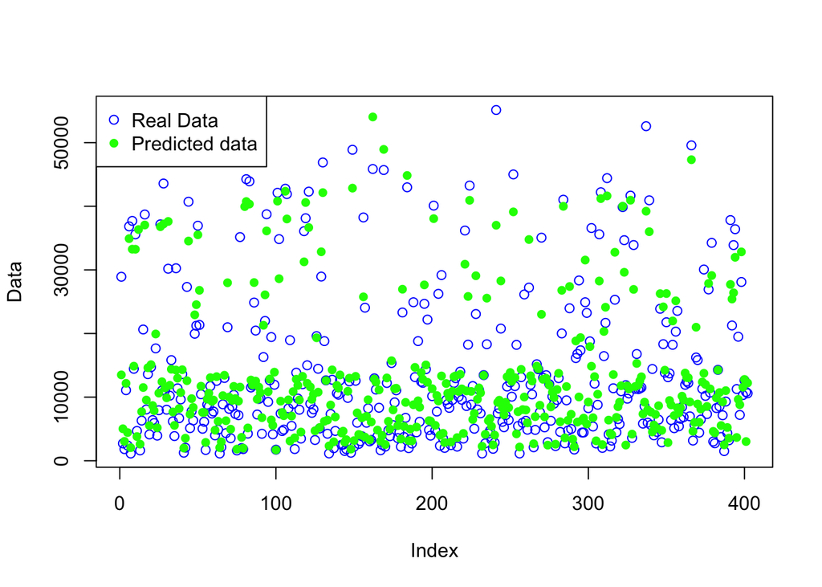

```r
coeffs <- model.interraction$coefficients

# Prediction the data on the test sample from the model with interactions
predicted.data.iter <- predict(model.interraction, newdata = test)

# Calculation of the difference between the predicted data and the real data
diff.data.iter <- abs(predicted.data.iter - real.data)

# Ploting the data by index, the difference in prediction is the vertical distance of a blue and a green point on the same index
{plot(real.data, ylab = 'Data', col='blue')
points(predicted.data.iter, col='green', pch=16)
legend('topleft', legend = c('Real Data', 'Predicted data'), col=c('blue', 'green'), bty = n, pch=c(1,16))}
```

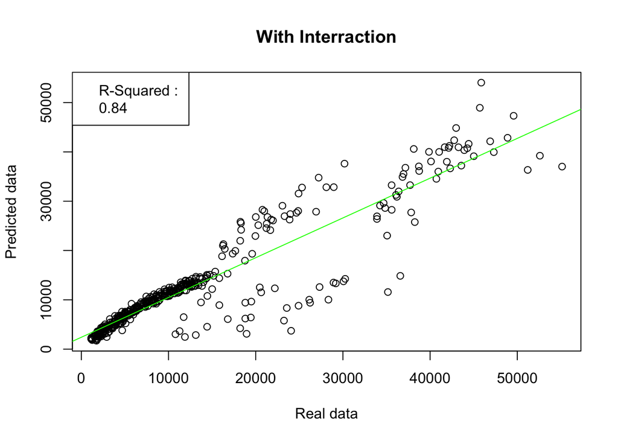

```
## accuracy :  84  %
```

```r
# Plotting the predicted values against the real data
mod <- lm(predicted.data.iter ~ real.data)
{plot(real.data, predicted.data.iter, xlab = 'Real data', ylab = 'Predicted data', title('With Interraction'))
  abline(mod$coefficients[1], mod$coefficients[2], col='green')
  legend('topleft', legend = c('R-Squared : ',round(summary(mod)$r.squared, 2)))}
```

We can see that the model with interactions has a better accuracy and feels more consistent as we might think of some links between variables.

### Final Test Prediction

The objective is to predict the expected medical expenses for a new customer: a male aged 30 with 2 children, who is a smoker with a BMI of 32, and who lives in the southeast of Ireland.

The fact that he is a male doesn’t affect the model as the sex parameter was not statistically significant.

```r
# Prediction of the new customer
prediction.custom <- function(age, regionNW, regionSE, regionSW, children, smoker, bmi){
  result <- age*coeffs[2] + regionNW*coeffs[3] + regionNW*coeffs[4] + regionNW*coeffs[5] + children*coeffs[6] + smoker*coeffs[7] + (1-smoker)*bmi*coeffs[8] + smoker*bmi*coeffs[9] + coeffs[1]
  return(result)
}

result <- prediction.custom(30, 0, 1, 0, 2, 1, 32 )
result
```

```
##      age
## 32749.31
```

*Hugo Deroche*